# Q2: What kinds of building markets does New Zealand have?

## 3.1 Who is in each cluster

```r
prof %>% group_by(cluster) %>%
  summarise(districts = n(), members = paste(sort(name), collapse = ", ")) %>%
  kable(caption = "Districts in each k-means cluster")
```

Districts in each k-means cluster

| cluster | districts | members |
| --- | --- | --- |
| Urban multi-unit | 9 | Auckland, Christchurch, Dunedin, Hamilton, Lower Hutt, Porirua, Queenstown-Lakes, Upper Hutt, Wellington |
| House-building belt | 32 | Ashburton, Carterton, Central Otago, Far North, Hastings, Hauraki, Horowhenua, Hurunui, Kaikoura, Kaipara, Kapiti Coast, Mackenzie, Manawatu, Marlborough, Masterton, Matamata-Piako, Napier, Nelson, Ne… |
| Regional low-intensity | 26 | Buller, Central Hawke’s Bay, Chatham Islands, Clutha, Gisborne, Gore, Grey, Invercargill, Kawerau, Opotiki, Otorohanga, Rangitikei, Rotorua, Ruapehu, South Taranaki, South Waikato, Southland, Stratfor… |

## 3.2 What makes each cluster different

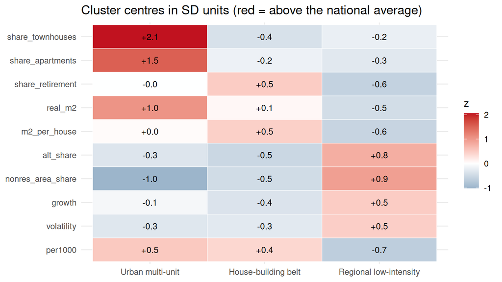

```r
prof %>%
  select(cluster, all_of(feats)) %>%
  mutate(across(all_of(feats), ~ as.numeric(scale(.x)))) %>%
  group_by(cluster) %>% summarise(across(everything(), mean)) %>%
  pivot_longer(-cluster, names_to = "feature", values_to = "z") %>%
  mutate(feature = factor(feature, levels = rev(feats))) %>%
  ggplot(aes(cluster, feature, fill = z)) +
  geom_tile(colour = "white") +
  geom_text(aes(label = sprintf("%+.1f", z)), size = 3.5) +
  scale_fill_gradient2(low = "#2a6f97", mid = "white", high = "#c1121f") +
  labs(title = "Cluster centres in SD units (red = above the national average)",
       x = NULL, y = NULL, fill = "z") +
  theme(legend.position = "right")
```

```r
prof %>%
  group_by(cluster) %>%
  summarise(districts = n(),
            `townhouses %` = 100 * median(share_townhouses),
            `apartments %` = 100 * median(share_apartments),
            `retirement %` = 100 * median(share_retirement),
            `real $/m²`    = median(real_m2),
            `m² per house` = median(m2_per_house),
            `alterations %` = 100 * median(alt_share),
            `non-res area %` = 100 * median(nonres_area_share),
            `growth (×)`   = exp(median(growth)),
            `dwellings /1,000` = median(per1000)) %>%
  kable(digits = 1, format.args = list(big.mark = ","),
        caption = "Cluster medians in original units")
```

Cluster medians in original units

| cluster | districts | townhouses % | apartments % | retirement % | real $/m² | m² per house | alterations % | non-res area % | growth (×) | dwellings /1,000 |
| --- | --- | --- | --- | --- | --- | --- | --- | --- | --- | --- |
| Urban multi-unit | 9 | 35.3 | 7.9 | 5.8 | 3,388.8 | 185.0 | 11.8 | 27.2 | 1.3 | 5.6 |
| House-building belt | 32 | 9.5 | 0.5 | 7.4 | 3,154.8 | 192.9 | 13.8 | 33.4 | 1.1 | 7.6 |
| Regional low-intensity | 26 | 10.8 | 0.2 | 0.5 | 3,026.4 | 176.0 | 23.0 | 55.0 | 1.6 | 3.0 |

# 4 Hierarchical clustering

Agglomerative clustering merges the two closest groups at every step. **Ward’s linkage** merges the pair that adds the least within-cluster variance, which makes it the closest relative of k-means. Complete and average linkage are fitted too, to show how much the linkage choice matters.

```r
hc <- list(Ward     = hclust(D, method = "ward.D2"),
           Complete = hclust(D, method = "complete"),
           Average  = hclust(D, method = "average"))
cuts <- map(hc, cutree, k = k_final)
```

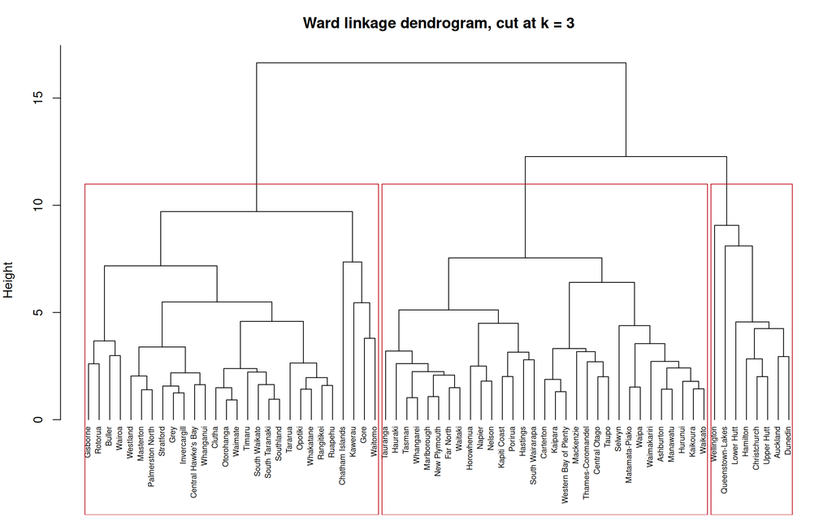

```r
par(mar = c(1, 4, 3, 1))
plot(hc$Ward, cex = 0.62, hang = -1, xlab = "", sub = "",
     main = paste("Ward linkage dendrogram, cut at k =", k_final))
rect.hclust(hc$Ward, k = k_final, border = "#c1121f")
```

## 4.1 Do the methods agree?

The **adjusted Rand index (ARI)** measures how far two partitions agree beyond chance. It is 1 for identical partitions and about 0 for random ones.

```r
ari <- function(a, b) {
  tab <- table(a, b); n <- sum(tab)
  s  <- sum(choose(tab, 2))
  sa <- sum(choose(rowSums(tab), 2)); sb <- sum(choose(colSums(tab), 2))
  e  <- sa * sb / choose(n, 2)
  (s - e) / ((sa + sb) / 2 - e)
}

tibble(method = names(cuts),
       `ARI with k-means` = map_dbl(cuts, ~ ari(km$cluster, .x)),
       `cluster sizes` = map_chr(cuts, ~ paste(sort(table(.x), decreasing = TRUE), collapse = " / "))) %>%
  kable(digits = 3, caption = paste0("Hierarchical partitions (k = ", k_final, ") vs k-means"))
```

Hierarchical partitions (k = 3) vs k-means

| method | ARI with k-means | cluster sizes |
| --- | --- | --- |
| Ward | 0.858 | 31 / 28 / 8 |
| Complete | 0.673 | 38 / 28 / 1 |
| Average | 0.054 | 65 / 1 / 1 |

```r
table(`k-means` = prof$cluster, `Ward` = cuts$Ward) %>% kable(caption = "k-means vs Ward, cross-tabulation")
```

k-means vs Ward, cross-tabulation

|  | 1 | 2 | 3 |
| --- | --- | --- | --- |
| Urban multi-unit | 1 | 8 | 0 |
| House-building belt | 30 | 0 | 2 |
| Regional low-intensity | 0 | 0 | 26 |

```r
disagree <- prof$name[match(cuts$Ward, unique(cuts$Ward[order(prof$cluster)]))
                      != match(km$cluster, unique(km$cluster[order(prof$cluster)]))]
```

Complete and average linkage chain single outliers into their own clusters, which is why their sizes are lopsided. Ward and k-means find essentially the same groups. They disagree only on: Masterton, Palmerston North, Porirua.

# 5 How stable are the clusters?

A cluster that disappears when the data change slightly should not be interpreted. Districts are resampled with replacement 200 times. Each time k-means is refitted, every original district is assigned to its nearest new centre, and the result is compared with the main solution using ARI.

```r
set.seed(seed)
nearest <- function(X, centers) apply(X, 1, function(r) which.min(colSums((t(centers) - r)^2)))
boot_ari <- map_dbl(1:200, function(b) {
  idx <- sample(nrow(X), replace = TRUE)
  kb  <- kmeans(X[idx, ], k_final, nstart = 25, iter.max = 50)
  ari(km$cluster, nearest(X, kb$centers))
})
```

```r
cat("Bootstrap ARI: median", round(median(boot_ari), 2),
    "  middle 90%", paste(round(quantile(boot_ari, c(0.05, 0.95)), 2), collapse = " to "), "\n")
```

```
## Bootstrap ARI: median 0.72   middle 90% 0.27 to 1
```

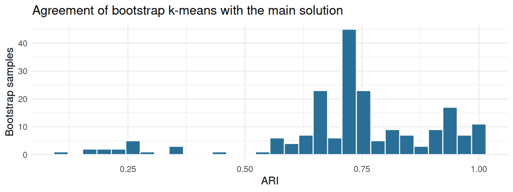

```r
ggplot(tibble(ari = boot_ari), aes(ari)) +
  geom_histogram(bins = 30, fill = "#2a6f97", colour = "white") +
  labs(title = "Agreement of bootstrap k-means with the main solution", x = "ARI", y = "Bootstrap samples")
```

## 5.1 Which districts are borderline?

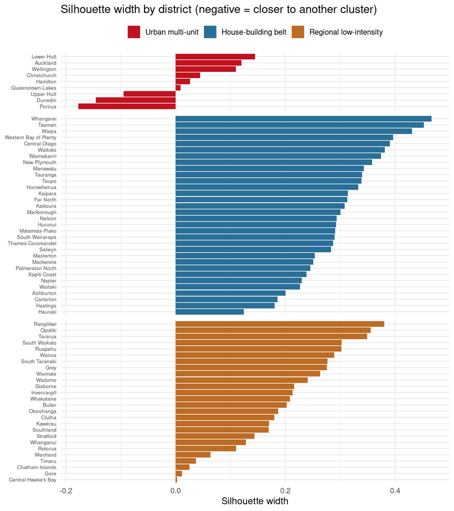

```r
sil <- silhouette(km$cluster, D)
prof$sil <- sil[, "sil_width"]
prof %>%
  ggplot(aes(sil, reorder(name, sil), fill = cluster)) +
  geom_col() +
  facet_grid(cluster ~ ., scales = "free_y", space = "free_y") +
  scale_fill_manual(values = clus_cols) +
  labs(title = "Silhouette width by district (negative = closer to another cluster)",
       x = "Silhouette width", y = NULL, fill = NULL) +
  theme(axis.text.y = element_text(size = 6.5), strip.text = element_blank())
```